# Study on the Differential Analysis of Alternative Splicing Based on the Median Value Jensen-Shannon Divergence

[figure not shown]

[figure not shown]

[Volume 42 Issue 6](https://jeit.ac.cn/en/article/2020/6)

Jun. 2020

Wenbin LIU, Bing WANG, Gang FANG, Xiaolong SHI, Peng XU. Study on the Differential Analysis of Alternative Splicing Based on the Median Value Jensen-Shannon Divergence[J]. Journal of Electronics & Information Technology, 2020, 42(6): 1392-1400. doi: 10.11999/JEIT190941

[output not shown]

# Study on the Differential Analysis of Alternative Splicing Based on the Median Value Jensen-Shannon Divergence

##### **doi:** 10.11999/JEIT190941 **cstr:** 32379.14.JEIT190941

- Wenbin LIU<sup>1, 2 , ,</sup>,
- Bing WANG<sup>1</sup>,
- Gang FANG<sup>2</sup>,
- Xiaolong SHI<sup>2</sup>,
- Peng XU<sup>2, 3</sup>
- 1.

  College of Computer Science and Artificial Intelligence, Wenzhou University, Wenzhou 325035, China
- 2.

  Institute of Computing Science and Technology, Guangzhou University, Guangzhou 510006, China
- 3.

  School of Computer Science and Information Technology, Qiannan Normal University for Nationalities, Duyun 558000, China

**Funds:** The National Key R&D Program of China (2019YFA0706402), The National Natural Science Foundation of China (61572367, 61573017, 61972107, 61972109)

### Abstract

- Alternative splicing is an important mechanism of protein diversity in a wide range of organisms, which plays an important role in the fine regulation of cell proliferation, differentiation, development, apoptosis and a series of important biological processes. In recent years, it is found that the occurrence of multiple complex diseases is often accompanied by the disordered expression of splicing isoforms. In order to study the difference of splicing isoforms on the whole distribution, a differential analysis method of Alternative Splicing (AS) based on the median value by Jensen-Shannon (JS) divergence is proposed in this paper. The results show the method can finds plenty of genes with significant differences in the overall distribution of splicing isoforms. These genes are not only concentrated in some cancer related pathways, but also in some signaling pathways based on alternative splicing regulation, cell division process and protein function. In addition, compared with the gene-level differential analysis, the genes with significant difference in alternative splicing also have better performance in survival analysis. In conclusion, the proposed method will lay a foundation for further revealing the mechanism of alternative splicing in cancer.

  **Keywords:**
  - Alternative splicing,
  - Cancer,
  - Jensen-Shannon (JS) divergence,
  - Kyoto Encyclopedia of Genes and Genomes (KEGG) pathway,
  - Driver gene

### 1. 引言

- 在真核生物中，一个基因翻译成相应蛋白质，需要通过3个步骤：(1)DNA转录成前体mRNA(pre-mRNA)；(2)前体mRNA再经过内含子(intron)去除外显子(exon)保留的剪接反应将保留的外显子拼接形成成熟mRNA；(3)成熟mRNA指导核糖体最终翻译成蛋白质。可变剪接(Alternative Splicing, AS)是指有些基因的一个前体mRNA通过选择不同的剪接位点组合，形成不同mRNA剪接异构体(isoform)的过程。最终，一个基因将通过可变剪接将翻译成多种蛋白质。常见的可变剪接模式主要分为7类，分别为外显子跳跃(Exon Skipping, ES)、可变供体剪接位点(Alternative Donor sites, AD)、可变受体剪接位点(Alternative Acceptor sites, AA)、内含子保留(Retained Intron, RI)、互斥外显子(Mutually Exclusive exons, ME)、可变启动子(Alternate Promoter, AP)和可变poly(A)位点(Alternate Terminator, AT)。人类的主要剪接模式为外显子跳跃(约占35%)，其次为可变受体剪接位点(约占16%)和可变供体剪接位点(约占15%)<sup>[1]</sup>。现有研究表明，大多数真核生物的蛋白质编码基因含有多个外显子，其中大约95%的基因均存在可变剪接事件<sup>[2]</sup>。根据对TCGA数据库中人类基因异构体数目的统计，仅有28.7%的基因只有一种剪接模式，剩余约71.3%的基因存在至少2个异构体，9.9%的基因存在6个以上的异构体。生物学研究表明：可变剪接是调节基因表达和产生蛋白质组多样性的重要机制，它们对细胞分化、发育、生理功能及其精细调节具有重要的影响<sup>[3]</sup>。

  近年来随着RNA-Seq技术的广泛应用，为深入研究可变剪接在生命过程的调控机制及其对疾病的影响提供了丰富的转录组数据。通过对RNA-Seq数据的分析，发现剪接异构体之间存在一种平衡性。可变剪接紊乱会导致各异构体之间原有的比例失衡，某些异构体表达量的改变，甚至产生新的异构体，从而破坏原有的生物学进程。当某些基因发生不规则剪接时，即通过可变剪接产生多种不同的转录异构体，各个不同的转录异构体编码出结构不同的蛋白质亚型，甚至具有不同的功能，如Bcl-X基因存在多种异构体，其中有2种具有拮抗功能的异构体，抑制细胞凋亡的异构体Bcl-Xl和促进细胞凋亡的异构体Bcl-Xs，现已在多种癌症类型中观察到Bcl-Xl的上调和Bcl-Xs的下调<sup>[4]</sup>。可变剪接的研究进一步促进了疾病的诊断和治疗，如Nek2基因的剪接异构体Nek2C与乳腺癌的发生密切相关，抑制Nek2C的表达是乳腺癌的潜在治疗手段，或者通过空间阻滞寡核苷酸治疗策略<sup>[5]</sup>，阻止剪接复合体对pre-mRNA的错误剪接，恢复正确mRNA亚型的表达。

  可变剪接紊乱可能对关键转录因子、信号分子、膜蛋白、分泌蛋白等的生成产生巨大的影响，从而导致多种人类疾病甚至是癌症的产生<sup>[6]</sup>，如帕金森综合征、乳腺癌相关脾脏络氨酸激活酶isoform-S<sup>[7]</sup>、人类上皮增长因子受体等<sup>[8]</sup>。因此，找寻异常的可变剪接有助于进一步揭示疾病发生、发展的机制。现阶段对于可变剪接差异分析主要是基于表达水平和剪接模式上的差异。Shen等人<sup>[9]</sup>提出了rMATS(robust Multivariate Analysis of Transcript Splicing)模型针对重复的RNA-Seq数据来检测差异可变剪接基因。欧书华等人<sup>[10]</sup>提出基于KL散度(Kullback-Leibler divergence)的RNA-Seq数据差异异构体比例检测方法来测差异可变剪接基因。Liu等人<sup>[11]</sup>通过对基因各剪接模式的PSI(Percent-Spliced-In)值进行统计学分析检测差异可变剪接基因。Zong等人<sup>[12]</sup>使用多因素比例风险回归法来检测差异可变剪接基因。Zhang等人<sup>[13]</sup>将深度学习与贝叶斯假设检验相结合来检测差异可变剪接基因。

### 2. 研究方法

#### 2.1 实验数据集

  本文从TCGA数据库网站(https://tcga-data.nci.nih.gov/tcga)分别下载了乳腺癌(BReast invasive CArcinoma, BRCA)、肝癌(LIver Hepatocellular Carcinoma, LIHC)和子宫内膜癌(Uterine Corpus Endometrial Carcinoma, UCEC)的基因表达数据和异构体表达数据，使用TPM(Transcripts Per Million)来衡量样本的表达丰度。且从TCGA SpliceSeq网站(https://bioinformatics.mdanderson.org/TCGASpliceSeq/)获取相应癌症样本各基因的剪接模式PSI表达数据。由于过低表达量的基因或异构体在癌症调控过程中往往起不到调节作用，且发生可变剪接的基因至少含2个异构体。本文筛选在50%以上样本中表达量至少为0.1 TPM的异构体，再剔除掉只有单个异构体的基因，最终各癌症数据集的样本个数、基因个数和对应的异构体个数如表1所示。

  **表 1** 癌症数据集统计信息

  | 癌症 | 癌症样本 | 正常样本 | 基因个数 | 异构体个数 |
  | --- | --- | --- | --- | --- |
  | BRCA | 1100 | 112 | 10178 | 33481 |
  | LIHC | 373 | 50 | 8871 | 26234 |
  | UCEC | 117 | 24 | 9765 | 30953 |

[figure not shown]

#### 2.3 基于中值的JS散度可变剪接差异分析方法

  在癌症和正常两种状态下，一个基因剪接异构体分布的差异可以反映由于可变剪接种类或模式的差异。因此，本文将利用异构体表达谱数据来研究基因的可变剪接的JS散度。给定一个有*k*个异构体的基因*x*, *x*<sup>T</sup>和*x*<sup>N</sup>分别为在癌症和正常状态的异构体表达量，则很容易根据每个剪接异构体的组成百分比*p*(*x*<sub>*i*</sub><sup>T</sup>)与*q*(*x<sub>i</sub>*<sup>N</sup>)，计算基因*x*在这对样本中的JS散度。然后，根据基因*x*的JS散度大小，研究其在癌症和正常两种状态剪接异构体分布差异的显著性。

  但是，TCGA数据库的大部分表达谱数据集均为非配对数据，即癌症和正常样本均来自不同的个体，因此，无法直接计算一个基因在两种状态下的可变剪接的JS散度。在统计分析中，由于中值不受极端值的影响，具有稳定性和可靠性的优点，常常用于刻画一个变量的代表值。因此，本文首先根据基因*x*的*k*个异构体分别在癌症组和正常组表达量中值，构建基因*x*在癌症和正常两种状态的代表表达向量*x*<sup>T</sup>和*x*<sup>N</sup>；然后，计算代表表达向量*x*<sup>T</sup>和*x*<sup>N</sup>中每个异构体的百分比；最后，计算基因*x*的可变剪接的JS散度。

  本文提出的基于中值的JS散度可变剪接差异分析方法步骤如下：

  步骤 1 确定基因*x*在癌症和正常两种状态下的代表异构体表达向量*x*<sup>T</sup>和*x*<sup>N</sup>；

  步骤 2 计算每个异构体的百分比*p*(*x*<sub>*i*</sub><sup>T</sup>)与*q*(*x*<sub>*i*</sub><sup>N</sup>)

  步骤 4 重复步骤1—步骤3，对每个基因的JS散度按照从大到小排序。

  总体上，本方法的通过中值构造基因各异构体在癌症和正常两种状态下的代表表达向量，在之后的运算中仅需对这对向量进行分析，无需对众多样本整体分析，使得本文方法的计算复杂度较低。本方法利用JS散度能找寻剪接异构体在整体分布差异较大的基因，避免了从单个基因或单个异构体分析导致忽略了基因内部异构体的整体分布差异。且与从剪接模式差异分析相比，由于一个剪接模式会产生两个剪接异构体，当一个基因仅发生一个剪接模式时，则能考虑到异构体整体分布的差异，当存在多个剪接模式时，则无法考虑到整体分布的差异，所以从剪接模式上考虑差异基因仍存在一定不足。

### 3. 实验结果及分析

#### 3.1 差异基因分析

  本文使用基于中值的JS散度可变剪接差异分析方法构建AS Model对癌症进行差异基因分析。同时分别对单个基因、单个异构体和Liu等人<sup>[11]</sup>方法根据各剪接模式的PSI值均使用t检验构建Gene Model, Isoform Model和PSI Model与AS Model进行对比。其中Gene Model使用基因表达数据，通过校正后的Pvalue(FDR)显著性进行重要差异基因排序。Isoform Model使用了异构体表达数据求得每个异构体的FDR，由于同一基因含多个异构体，则选取FDR值最小的异构体作为该基因的显著性值。同理，PSI Model中同一基因可能存在多个剪接模式，选取FDR值最小的剪接模式作为该基因的显著性值。因为FDR和JS散度值没有可比性，所以本文按排名来评价基因的差异性。

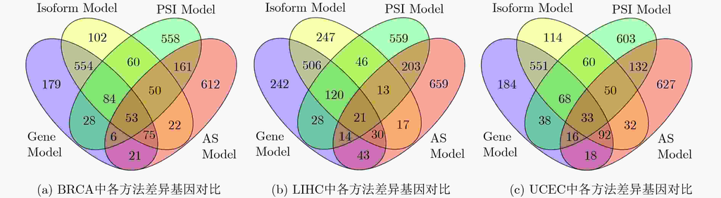

  **图 1** 4种方法差异基因的韦恩图

[figure not shown]

  首先，Gene Model和Isoform Model在检测到的差异基因3种癌症中的重合度均高达约70%，主要由于Isoform Model是根据基因中最显著的异构体来寻差异基因，而通常在基因表达差异较大的情况下，其内部异构体也很大概率上存在较大差异。Isoform Model仍能检测出部分Gene Model无法检测到的差异基因，是由于它们基因层次上不显著差异，但其内部存在显著差异的异构体。一个剪接模式对应产生两个剪接异构体，PSI Model是根据剪接模式找寻差异基因，这使得该模型检测到的差异基因与Isoform Model, AS Model重合度相对较高。AS Model与其它3种方法找寻差异基因的方式不同，这使得找寻的差异基因存在较大的差异。存在大部分使用AS Model检测到的差异基因却无法被Gene Model, Isoform Model和PSI Model检测到，是由于这些基因在基因表达水平上差异不大，且其内部异构体存在一定差异但无明显差异，而AS Model恰能考虑到同一基因各异构体的整体分布差异从而找到该差异基因。因此，从单个异构体的差异出发，无法检测出在剪接异构体整体分布上具有显著差异的基因。

#### 3.2 KEGG通路分析

  因为Gene Model, Isoform Model, PSI Model的差异分析原理大致相同，且得到的差异基因重合度较高，两者间的差异仅是使用了不同表达水平的癌症数据集。所以在之后的分析中主要针对基于基因表达谱的Gene Model与本文所提出基于异构体表达谱的AS Model进行比较，分析从基因表达水平和异构体表达水平检测到的差异基因在多方面的异同点。

  **表 2** KEGG通路分析

  | 癌症 | 通路(Gen Model) | 通路(AS Model) |
  | --- | --- | --- |
  |  | Focal adhesion | Cell cycle |
  |  | PI3K-Akt signaling pathway | p53 signaling pathway |
  |  | Tight junction | Pathways in cancer |
  |  | Regulation of lipolysis in adipocytes | Oocyte meiosis |
  | BRCA | Pathways in cancer | Viral carcinogenesis |
  |  | Rap1 signaling pathway | Adherens junction |
  |  | cAMP signaling pathway | Purine metabolism |
  |  | ABC transporters | PI3K-Akt signaling pathway |
  |  | Cell adhesion molecules (CAMs) | Hippo signaling pathway |
  |  | Leukocyte transendothelial migration | Metabolic pathways |
  |  | Metabolic pathways | Metabolic pathways |
  |  | Fatty acid degradation | Phagosome |
  |  | Protein processing in endoplasmic reticulum | Fc gamma R-mediated phagocytosis |
  |  | Proteasome | Leishmaniasis |
  | LIHC | mTOR signaling pathway | Homologous recombination |
  |  | AMPK signaling pathway | Sphingolipid metabolism |
  |  | Valine, leucine and isoleucine degradation | ECM-receptor interaction |
  |  | Spliceosome | Cell cycle |
  |  | Ubiquitin mediated proteolysis | Fanconi anemia pathway |
  |  | Insulin signaling pathway | Ribosome biogenesis in eukaryotes |
  |  | Vascular smooth muscle contraction | Osteoclast differentiation |
  |  | cGMP-PKG signaling pathway | Cell cycle |
  |  | Focal adhesion | Adherens junction |
  |  | MAPK signaling pathway | Axon guidance |
  | UCEC | Proteoglycans in cancer | Phagosome |
  |  | Calcium signaling pathway | Rheumatoid arthritis |
  |  | Platelet activation | AMPK signaling pathway |
  |  | Adherens junction | PPAR signaling pathway |
  |  | Oxytocin signaling pathway | ECM-receptor interaction |
  |  | Ras signaling pathway | Platelet activation |

[figure not shown]

#### 3.3 驱动基因分析

  为了进一步研究这些基因之间的互作关系，本文将BRCA, LIHC和UCEC3种癌症的所关联的驱动基因结合STRING数据库(http://string-db.org/)进行蛋白互作用网络(Protein Protein Interaction network，PPI network)分析。以乳腺癌结果为例，结果如图2所示，AS Model识别的差异驱动基因形成的PPI网络的关系更为密切，其结果要明显好于Gene Model，在另两种癌症中有此结果。由AS Model构建的PPI网络可知，这些基因并不是孤立存在，说明这些属于差异可变剪接的驱动基因并不是单一对癌症的发生、发展起到决定性作用，更多的是通过基因间的相互作用，形成调控网络共同对癌症进行调节。总的来说，有一部分癌症驱动基因的可变剪接紊乱是诱发癌症产生的重要因素，且这些基因之间存在密切的联系，可变剪接的紊乱会导致翻译后的蛋白质相互作用发生改变。

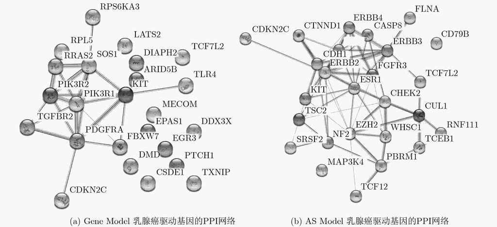

  **图 2** 乳腺癌驱动基因的PPI网络

[figure not shown]